# Chapter8

```r
library(fpp2)
library(tseries)
```

## Exercitiul 1

Explain the differences among these figures. Do they all indicate that the data are white noise?

Why are the critical values at different distances from the mean of zero? Why are the autocorrelations different in each figure when they each refer to white noise?

Valorile critice demonstreaza faptul ca sunt la distante diferite fata de zero. Distanta diferita este cauzata de numarul de observatii realizate. Cu cat sunt mai multe observatii intr-un set de date care indica white noise, cu atat apare mai putin noise in estimarile corelarii.

## Exercitiul 2

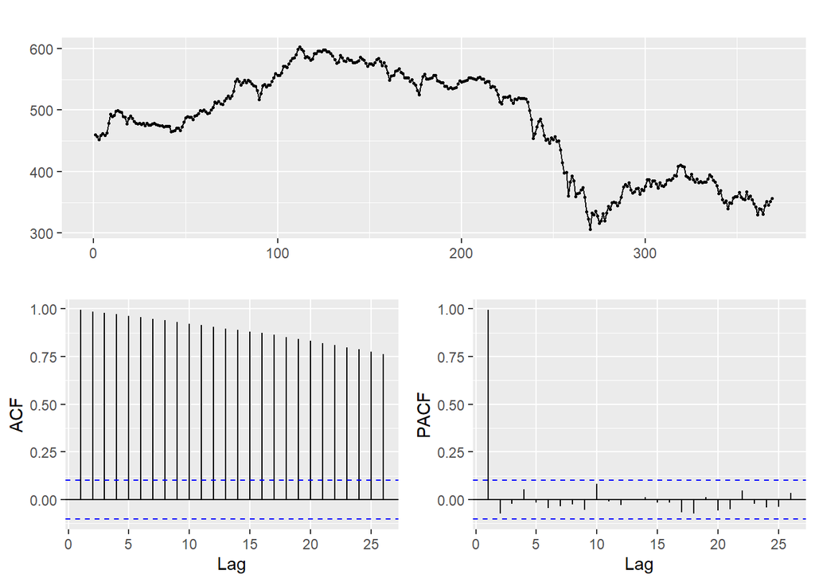

```r
ggtsdisplay(ibmclose)
```

Ggtsdisplay ploteaza o serie de timp cu ACF si PACF. ACF reprezinta corelarea unei serii cu valorile de lag (decalate). PACF gaseste corelarea unei serii cu valorile reziduale.

## Exercitiul 3

For the following series, find an appropriate Box-Cox transformation and order of differencing in order to obtain stationary data.

# usnetelec

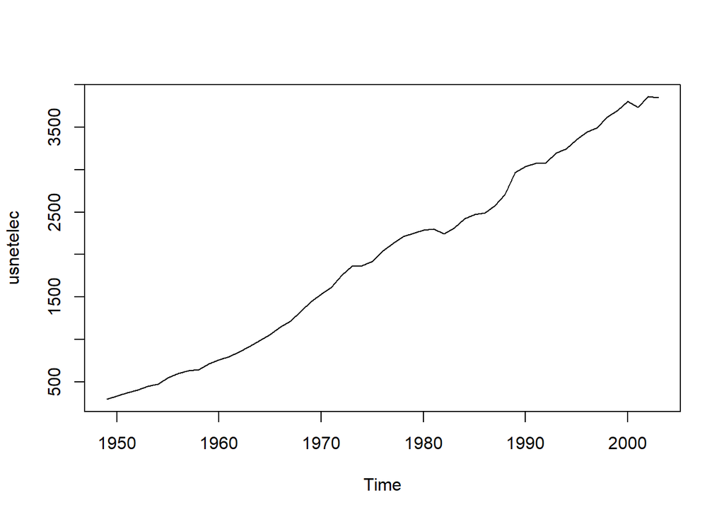

```r
plot(usnetelec)
```

Avand in vedere forma seriei, putem observa o crestere usor liniara

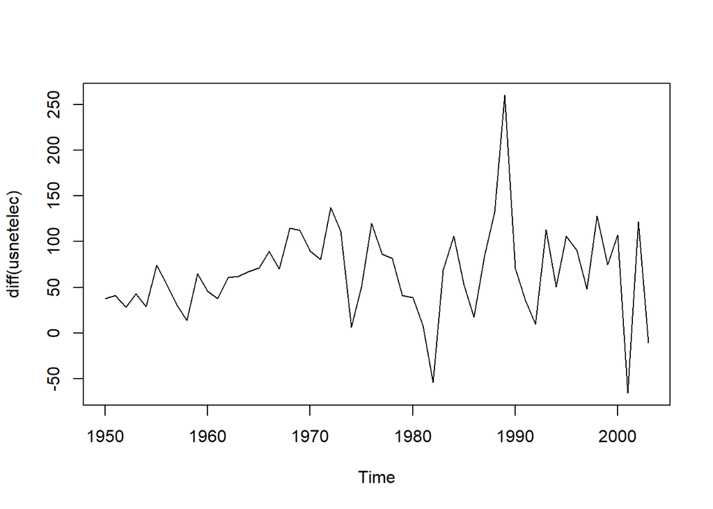

```r
plot(diff(usnetelec))
```

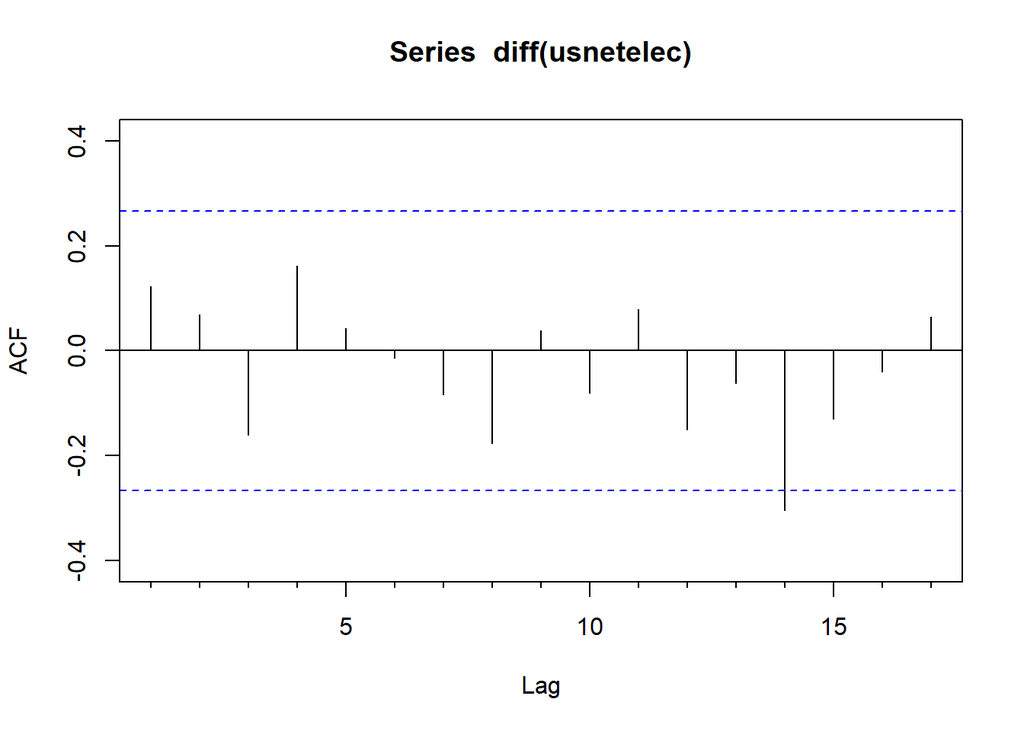

```r
Acf(diff(usnetelec))
```

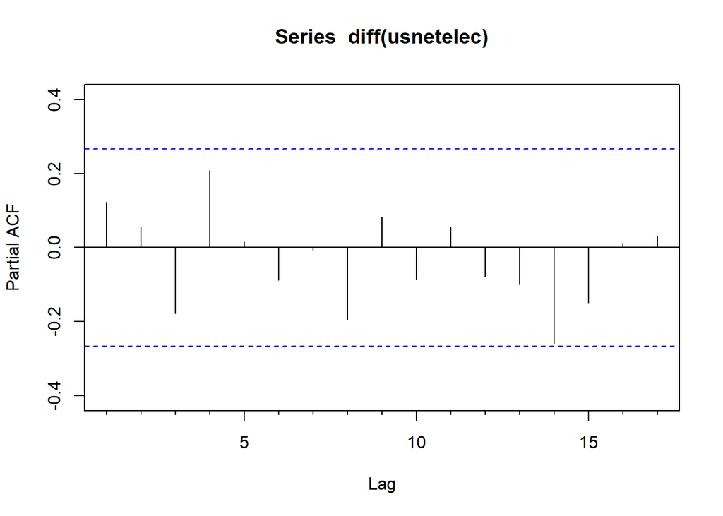

```r
Pacf(diff(usnetelec))
```

Functiile ACF si PACF arata ca diferentele dintre seriile de date se comporta aproape ca un white noise

# usgdp

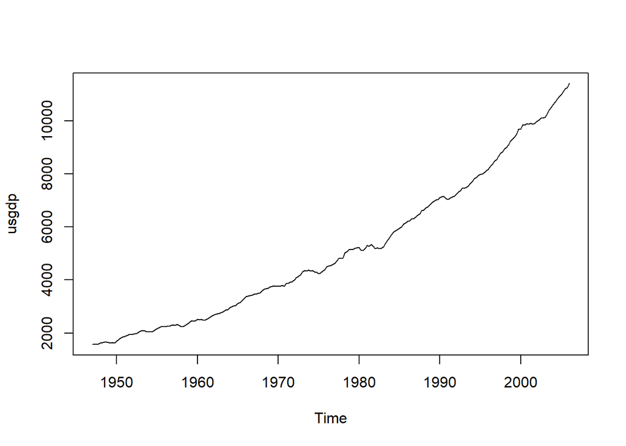

```r
plot(usgdp)
```

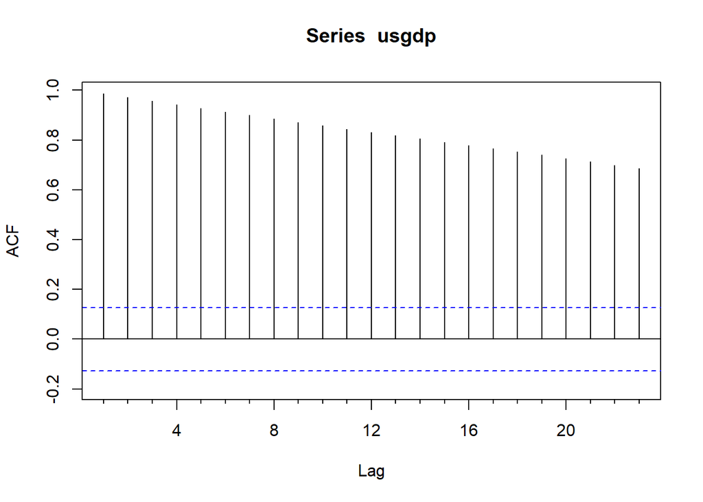

```r
Acf(usgdp)
```

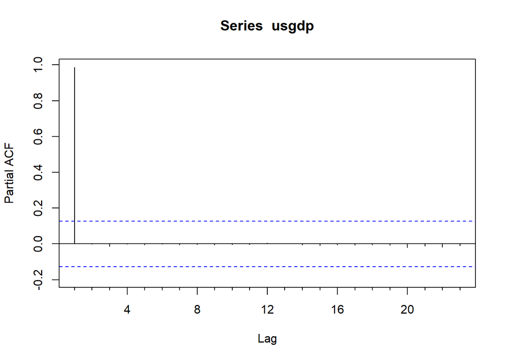

```r
Pacf(usgdp)
```

```r
lambda = BoxCox.lambda(usgdp)
```

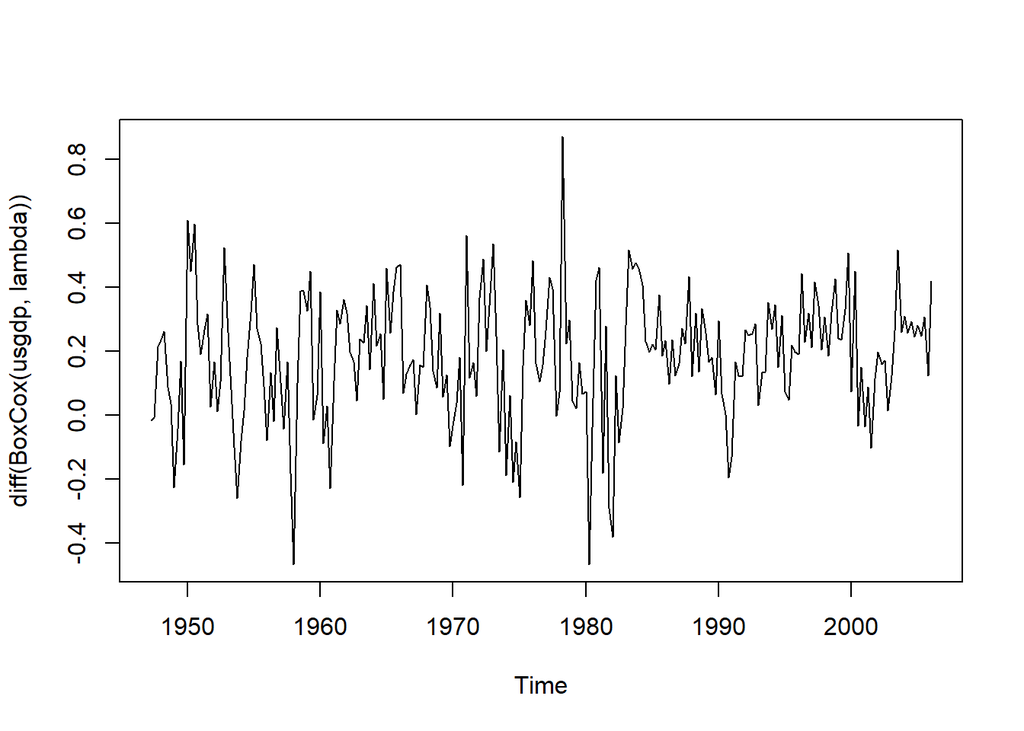

```r
plot(diff(BoxCox(usgdp,lambda)))
```

Vom alege o valoare lambda pentru a diferentia cu o anumita putere

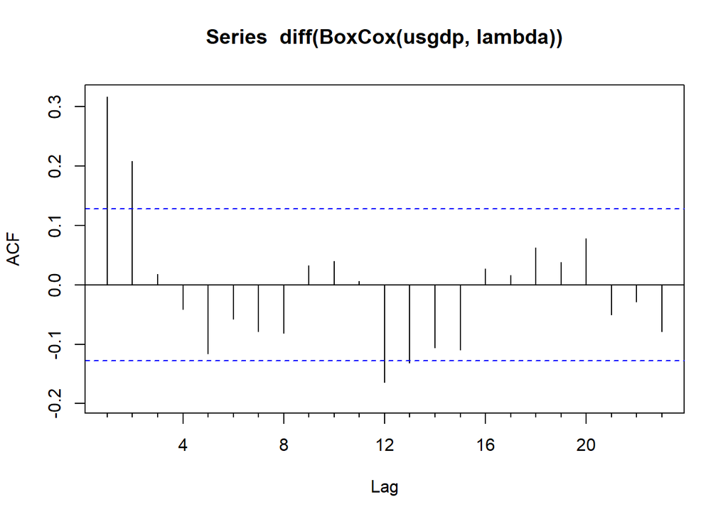

```r
Acf(diff(BoxCox(usgdp, lambda)))
```

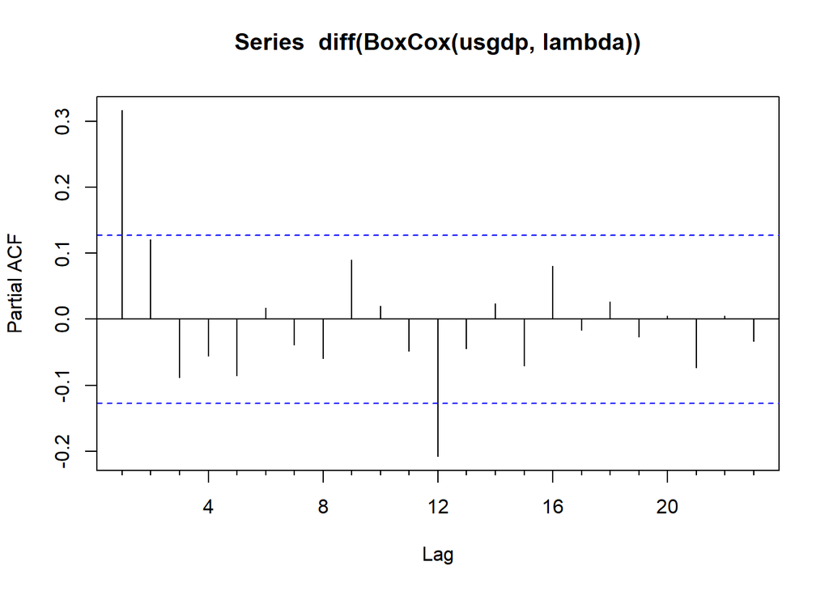

```r
Pacf(diff(BoxCox(usgdp, lambda)))
```

Dupa diferentierea realizata cu valoarea lambda putem observa ca seria de timp este stationara

# mcopper

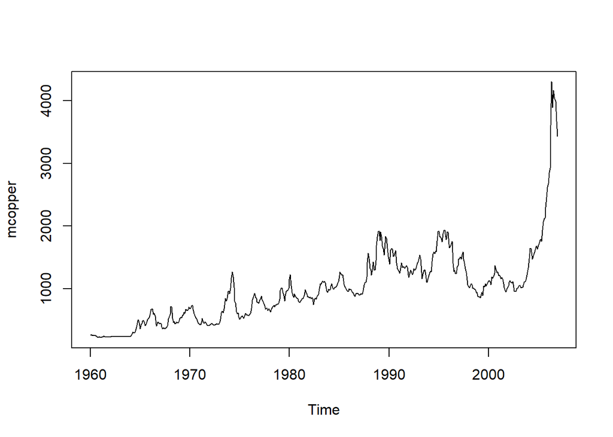

```r
plot(mcopper)
```

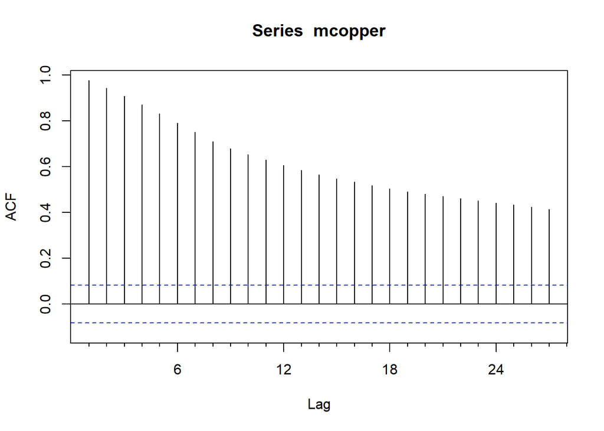

```r
Acf(mcopper)
```

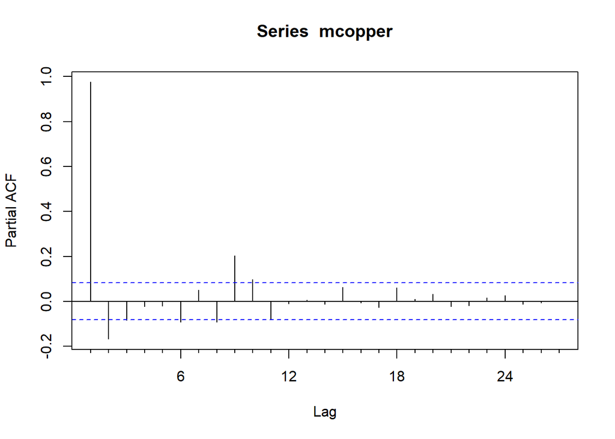

```r
Pacf(mcopper)
```

```r
lambda = BoxCox.lambda(mcopper)
```

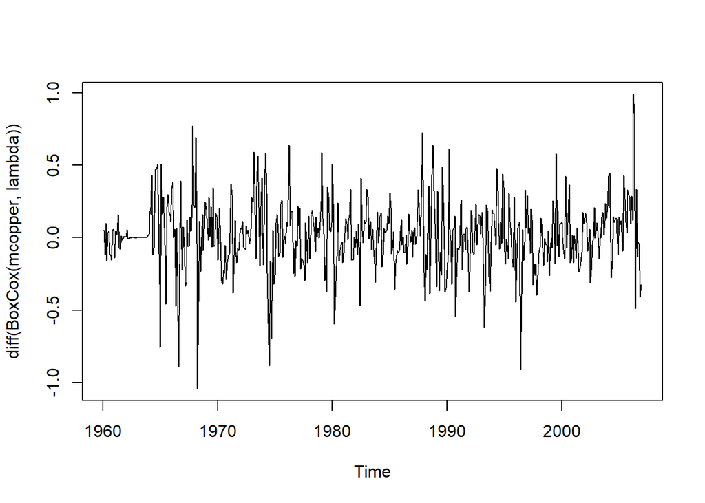

```r
plot(diff(BoxCox(mcopper, lambda)))
```

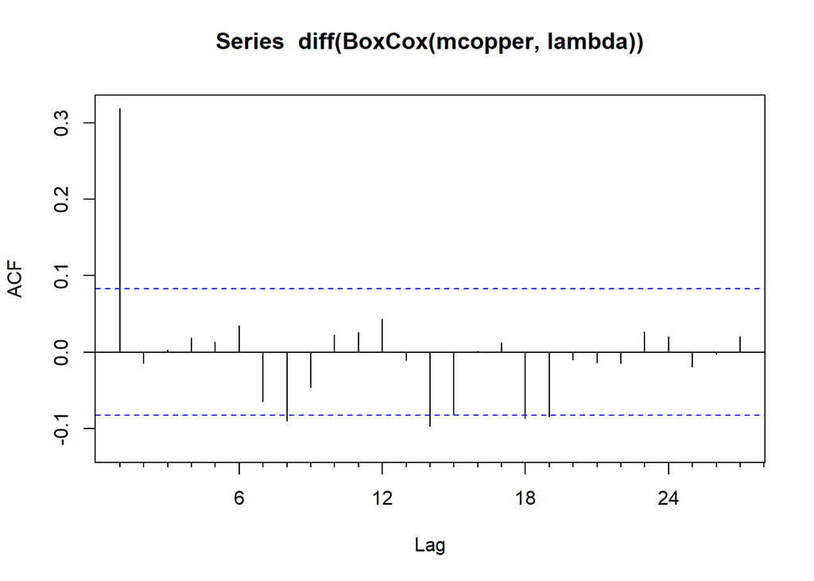

```r
Acf(diff(BoxCox(mcopper, lambda)))
```

ACF scade rapid cu cateva perturbatii pentru valorile mari de lag

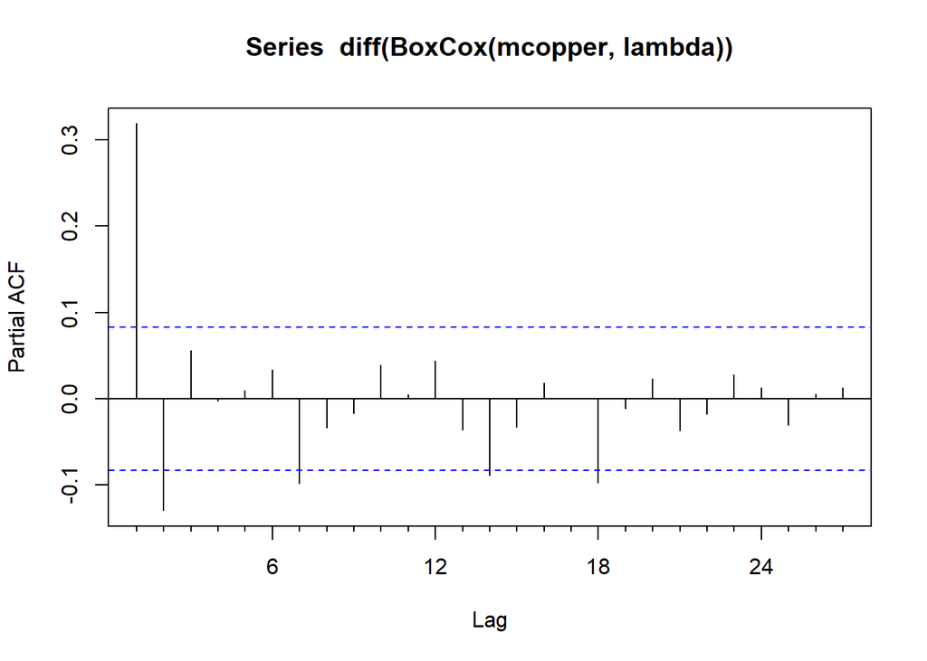

```r
Pacf(diff(BoxCox(mcopper, lambda)))
```

ACF si PACF sunt stationare

# enplanements

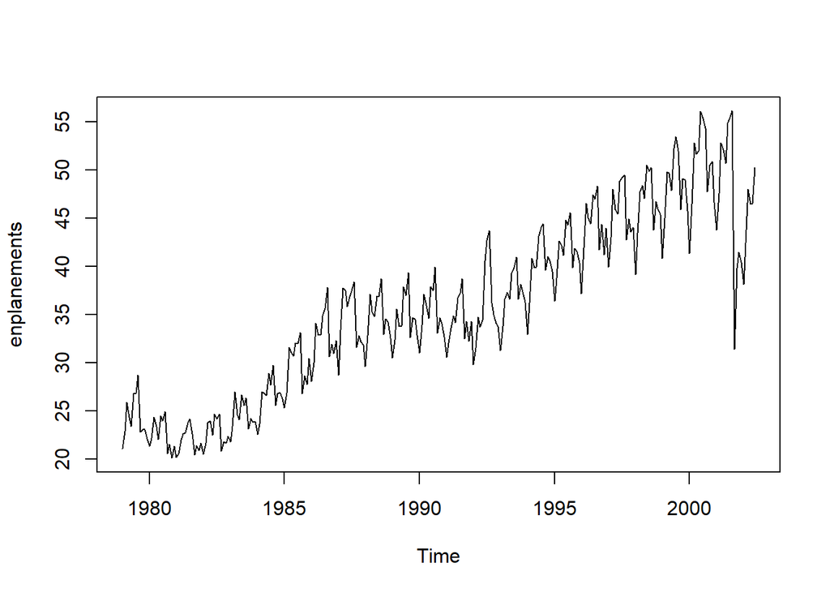

```r
plot(enplanements)
```

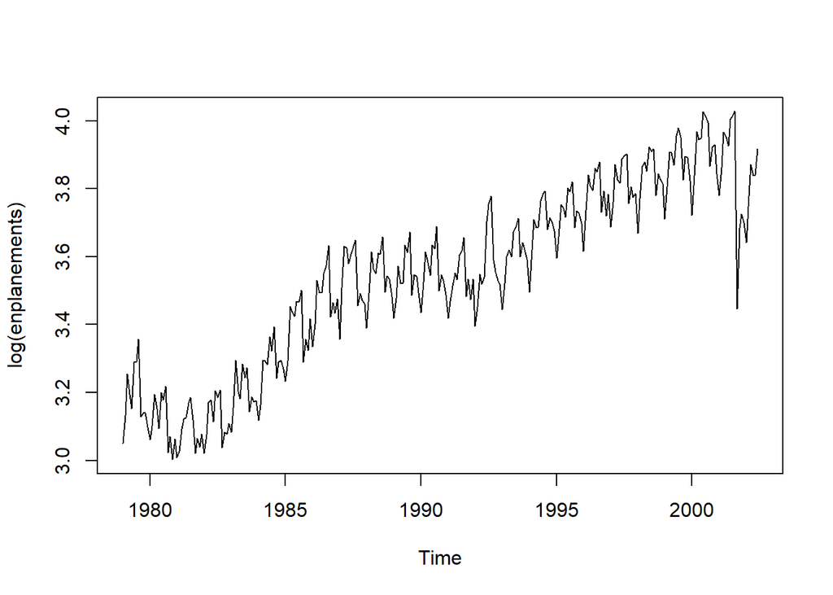

```r
plot(log(enplanements))
```

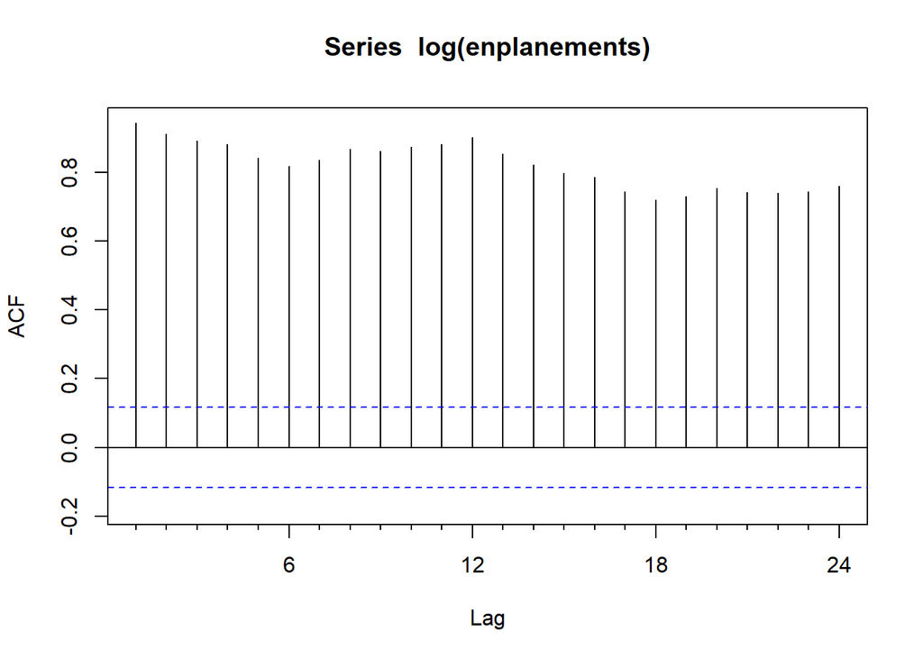

```r
Acf(log(enplanements))
```

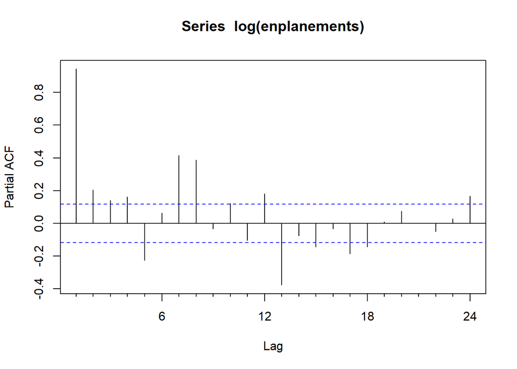

```r
Pacf(log(enplanements))
```

Datele trebuie diferentiate pentru a aplica modelul ARIMA. Cand aplicam log pe ACF, datele nu converg catre valori critice

Seria de timp trebuie diferentiata pentru a aplica modelul Arima. Datele sunt sezoniere si trebuie diferentiate cu un lag egal cu numarul de sezoane

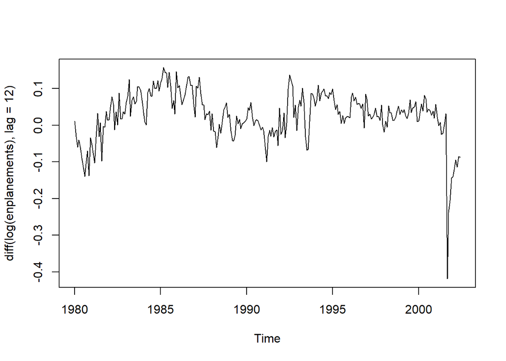

```r
plot(diff(log(enplanements), lag = 12))
```

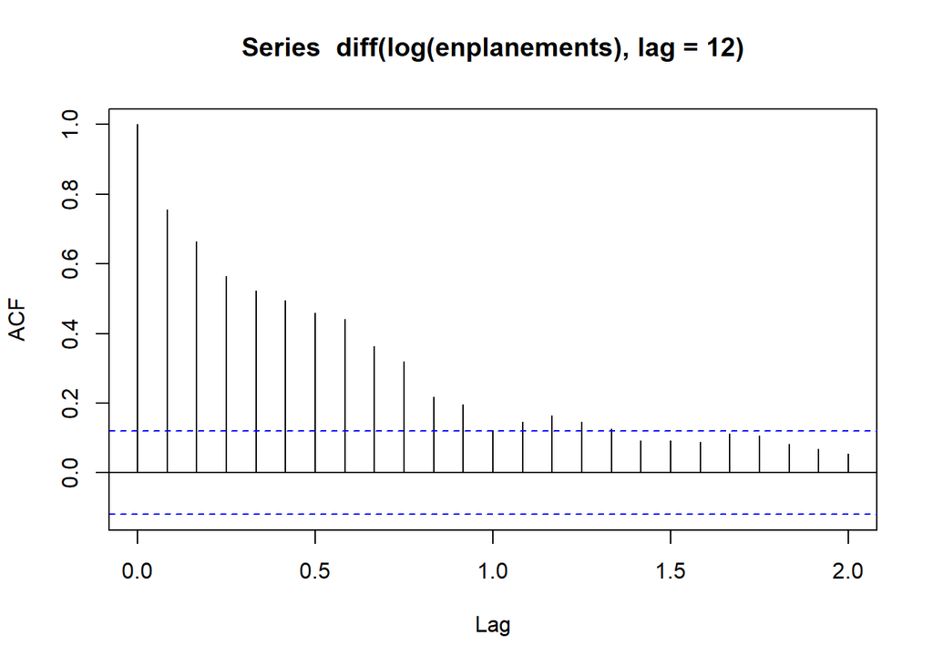

```r
acf(diff(log(enplanements), lag = 12))
```

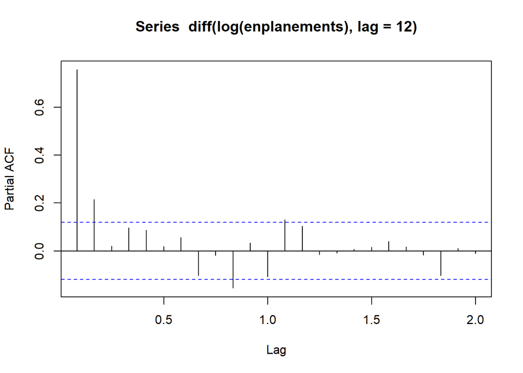

```r
pacf(diff(log(enplanements), lag = 12))
```

Trebuie diferentiate de doua ori

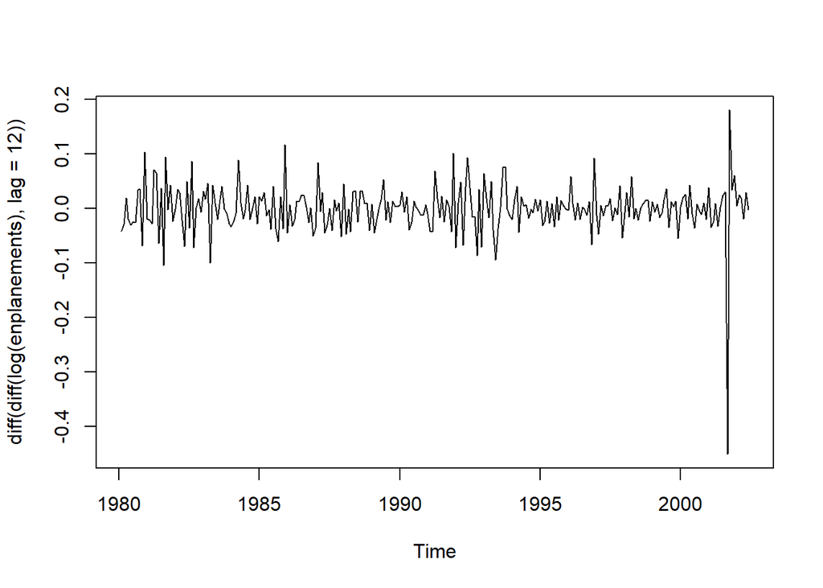

```r
plot(diff(diff(log(enplanements), lag = 12)))
```

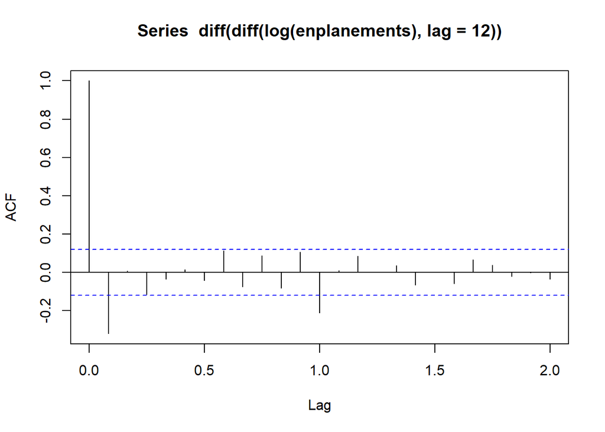

```r
acf(diff(diff(log(enplanements), lag = 12)))
```

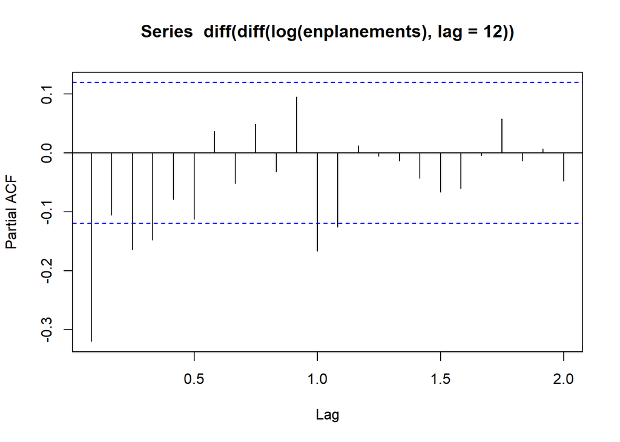

```r
pacf(diff(diff(log(enplanements), lag = 12)))
```

# visitors

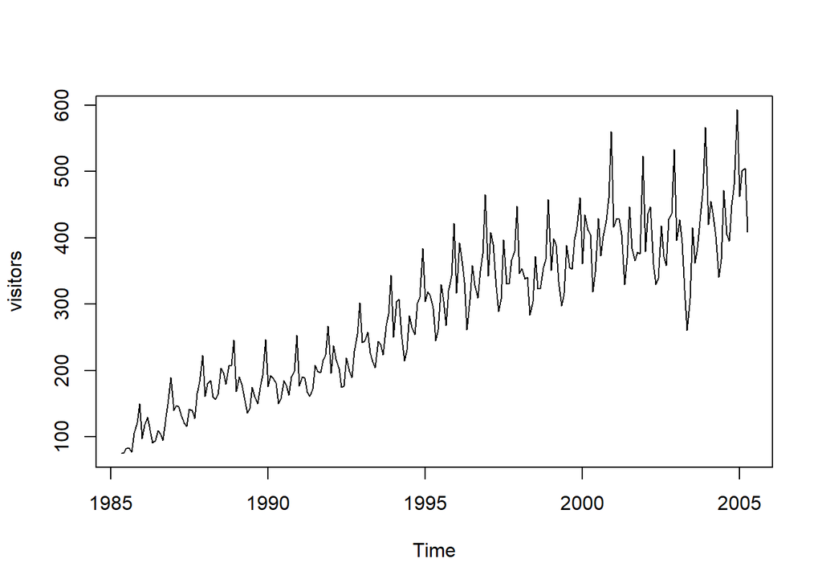

```r
plot(visitors)
```

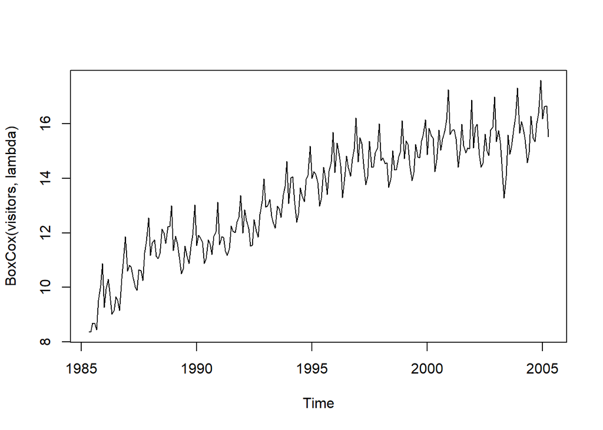

```r
lambda = BoxCox.lambda(visitors)
plot(BoxCox(visitors, lambda))
```

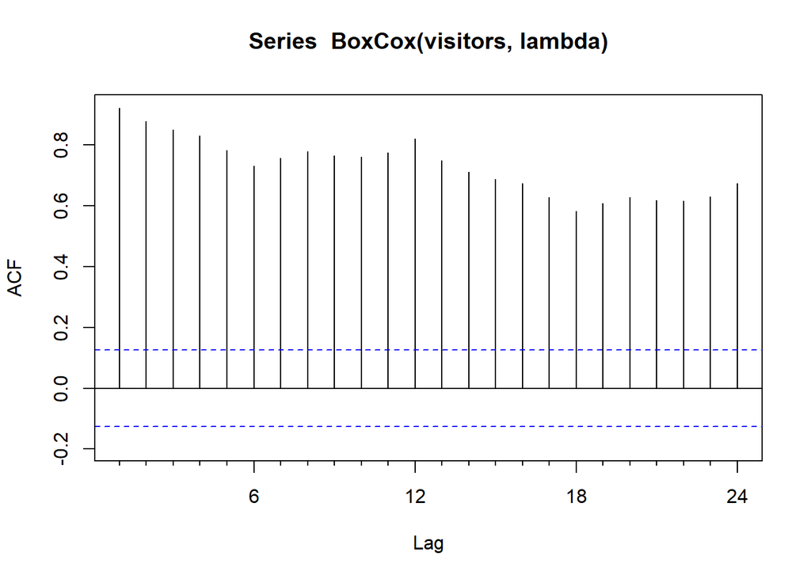

```r
Acf(BoxCox(visitors, lambda))
```

Avand in vedere modul lent prin care valorile scad lent, seria de date trebuie diferentiata

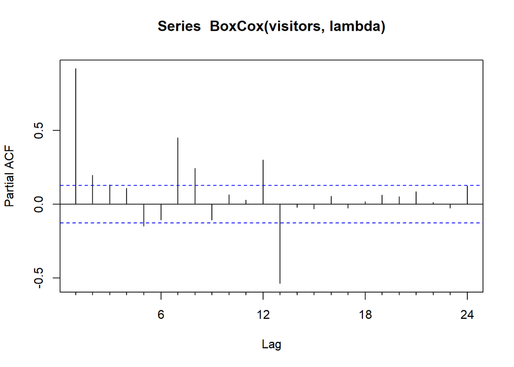

```r
Pacf(BoxCox(visitors, lambda))
```